# costa-rican-household poverty-prediction

```python
import os
```

```python
import pandas as pd
import numpy as np
import lightgbm as lgb
import matplotlib.pyplot as plt
```

```python
print(os.listdir("../input"))
```

```
['sample_submission.csv', 'test.csv', 'train.csv']
```

コンテスト参加ボタンを押して、そのまま新規カーネル追加ボタンを押すと、最初からinputディレクトリに必要なデータセットが配置されています。これもとても楽です。

```python
train_df = pd.read_csv('../input/train.csv')
len(train_df)
```

```
9557
```

学習用のデータは約9500行。

```python
train_df.head()
```

|  | Id | v2a1 | hacdor | rooms | hacapo | v14a | refrig | v18q | v18q1 | r4h1 | ... | SQBescolari | SQBage | SQBhogar_total | SQBedjefe | SQBhogar_nin | SQBovercrowding | SQBdependency | SQBmeaned | agesq | Target |
| --- | --- | --- | --- | --- | --- | --- | --- | --- | --- | --- | --- | --- | --- | --- | --- | --- | --- | --- | --- | --- | --- |
| 0 | ID_279628684 | 190000.0 | 0 | 3 | 0 | 1 | 1 | 0 | NaN | 0 | ... | 100 | 1849 | 1 | 100 | 0 | 1.000000 | 0.0 | 100.0 | 1849 | 4 |
| 1 | ID_f29eb3ddd | 135000.0 | 0 | 4 | 0 | 1 | 1 | 1 | 1.0 | 0 | ... | 144 | 4489 | 1 | 144 | 0 | 1.000000 | 64.0 | 144.0 | 4489 | 4 |
| 2 | ID_68de51c94 | NaN | 0 | 8 | 0 | 1 | 1 | 0 | NaN | 0 | ... | 121 | 8464 | 1 | 0 | 0 | 0.250000 | 64.0 | 121.0 | 8464 | 4 |
| 3 | ID_d671db89c | 180000.0 | 0 | 5 | 0 | 1 | 1 | 1 | 1.0 | 0 | ... | 81 | 289 | 16 | 121 | 4 | 1.777778 | 1.0 | 121.0 | 289 | 4 |
| 4 | ID_d56d6f5f5 | 180000.0 | 0 | 5 | 0 | 1 | 1 | 1 | 1.0 | 0 | ... | 121 | 1369 | 16 | 121 | 4 | 1.777778 | 1.0 | 121.0 | 1369 | 4 |

5 rows × 143 columns

カラムはとても多い模様。 とても雑ですが、submitすることが目的なので、一旦欠損値のあるカラムを除外し、相関でソートしていくつかの特徴量だけに絞ってしまいます。

カラムが多いためか、info関数が省略された表示になってしまったので、さくっと欠損値があるカラムだけループで調べます。

```python
for column_name in train_df.columns:
    sliced_df = train_df.loc[:, [column_name]]
    sliced_df = sliced_df[~sliced_df[column_name].isnull()]
    if len(sliced_df) != len(train_df):
        null_exists = True
    else:
        null_exists = False
    if null_exists:
        print('[%s]' % column_name)
        print('nan value exists : %s / %s' % (len(sliced_df), len(train_df)))
        print('-------')
```

```
[v2a1]
nan value exists : 2697 / 9557
-------
[v18q1]
nan value exists : 2215 / 9557
-------
[rez_esc]
nan value exists : 1629 / 9557
-------
[meaneduc]
nan value exists : 9552 / 9557
-------
[SQBmeaned]
nan value exists : 9552 / 9557
-------
```

```python
delete_target_column_list = [
    'v2a1', 'v18q1', 'rez_esc', 'meaneduc', 'SQBmeaned']
for delete_target_column in delete_target_column_list:
    del train_df[delete_target_column]
```

長くても省略せずに表示したいため、Pandasの設定を調整します。（300行・列まで表示）

```python
pd.set_option('display.max_rows', 300)
pd.set_option('display.max_columns', 300)
df_corr = train_df.corr()
df_corr.loc[['Target']].T.sort_values(
    by='Target', ascending=False)
```

|  | Target |
| --- | --- |
| Target | 1.000000 |
| cielorazo | 0.304421 |
| escolari | 0.302305 |
| SQBescolari | 0.296577 |
| eviv3 | 0.294222 |
| epared3 | 0.292451 |
| pisomoscer | 0.280284 |
| paredblolad | 0.261274 |
| etecho3 | 0.257378 |
| SQBedjefe | 0.246368 |
| v18q | 0.238864 |
| rooms | 0.226208 |
| instlevel8 | 0.214351 |
| qmobilephone | 0.199707 |
| computer | 0.183113 |
| lugar1 | 0.173359 |
| bedrooms | 0.166943 |
| hogar_adul | 0.160133 |
| elimbasu1 | 0.160051 |
| television | 0.157065 |
| energcocinar2 | 0.156457 |
| tipovivi2 | 0.143891 |
| estadocivil3 | 0.129730 |
| refrig | 0.126792 |
| age | 0.117620 |
| mobilephone | 0.106421 |
| r4h2 | 0.101253 |
| sanitario2 | 0.088663 |
| area1 | 0.087131 |
| instlevel9 | 0.083856 |

[output cut: 103 more lines]

（とても）大雑把に確認したところ、正の相関も負の相関も、強い相関のものはないようです。

```python
target_column_list = [
    'cielorazo',
    'escolari',
    'SQBescolari',
    'eviv3',
    'epared3',
    'pisomoscer',
    'paredblolad',
    'etecho3',
    'SQBedjefe',
    'v18q',
    'Target',
    ]
```

```python
train_df = train_df.loc[:, target_column_list]
```

ついでに、学習データの答えのデータ（今回は1, 2, 3, 4の4つのクラス）の分布を確認しておきます。

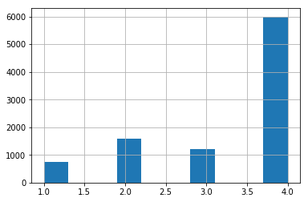

```python
_ = train_df.Target.hist(bins=10)
```

```python
X = train_df.copy()
del X['Target']
X = X.values
```

```python
X.shape
```

```
(9557, 10)
```

```python
y = train_df.loc[:, ['Target']].values
y = y.reshape(y.shape[0])
```

```python
y.shape
```

```
(9557,)
```

LGBMのクラス分類器を用意していきます。 scikit-learnに合わせたAPIも提供されているそうで、学習コストを抑えるためにそちらを利用します。（Prophet触ってみたときも思いましたが、とても楽です・・）

```python
gbm = lgb.LGBMClassifier()
gbm.fit(X=X, y=y)
```

```
LGBMClassifier(boosting_type='gbdt', class_weight=None, colsample_bytree=1.0,
        importance_type='split', learning_rate=0.1, max_depth=-1,
        min_child_samples=20, min_child_weight=0.001, min_split_gain=0.0,
        n_estimators=100, n_jobs=-1, num_leaves=31, objective=None,
        random_state=None, reg_alpha=0.0, reg_lambda=0.0, silent=True,
        subsample=1.0, subsample_for_bin=200000, subsample_freq=0)
```

```python
lgb.LGBMClassifier(boosting_type='gbdt', class_weight=None, colsample_bytree=1.0,
        learning_rate=0.1, max_depth=-1, min_child_samples=20,
        min_child_weight=0.001, min_split_gain=0.0, n_estimators=100,
        n_jobs=-1, num_leaves=31, objective=None, random_state=None,
        reg_alpha=0.0, reg_lambda=0.0, silent=True, subsample=1.0,
        subsample_for_bin=200000, subsample_freq=0)
```

```
LGBMClassifier(boosting_type='gbdt', class_weight=None, colsample_bytree=1.0,
        importance_type='split', learning_rate=0.1, max_depth=-1,
        min_child_samples=20, min_child_weight=0.001, min_split_gain=0.0,
        n_estimators=100, n_jobs=-1, num_leaves=31, objective=None,
        random_state=None, reg_alpha=0.0, reg_lambda=0.0, silent=True,
        subsample=1.0, subsample_for_bin=200000, subsample_freq=0)
```

最後に、推論対象のデータ（test.csv）を読み込んで、推論して結果（submission.csv）を保存します。

```python
test_df = pd.read_csv('../input/test.csv')
len(test_df)
```

```
23856
```

```python
test_target_column_list = []
for target_column in target_column_list:
    if target_column == 'Target':
        continue
    test_target_column_list.append(target_column)
```

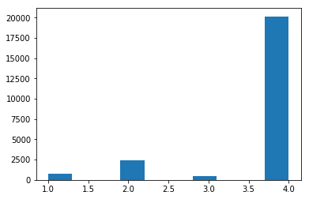

```python
X_test = test_df.loc[:, test_target_column_list].values
y_pred = gbm.predict(X=X_test)
_ = plt.hist(x=y_pred)
```

```python
submission_df = test_df.loc[:, ['Id']]
submission_df['Target'] = y_pred
submission_df.to_csv('./submission.csv', encoding='utf-8', index=False)
```